# Projekt Analiza Danych

Łukasz Pyrek

2022-11-18

```r
library(plyr)
library(tidyr)
library(dplyr)
library(gapminder)
library(ggplot2)
library(tibble)
library(ggrepel)
```

# **Wczytanie i czyszczenie danych**

Wczytanie danych do listy “dane” oraz zamienienie ich z szerokich na wąskie.

```r
path = paste(getwd() ,"/Data/", sep = "")
files <- list.files(path = path, pattern = "*.csv")
dane <- list()

for (file in files){
  temp_name <- file
  file <- tibble(read.csv(paste(path,file,sep = ""))) %>%
    gather("year", !!temp_name , -country)
  dane <- append(dane,list(file))
}
```

Usuwanie “X” z kolumny “years”

```r
for(i in 1:length(dane)){
  dane[[i]]$year <- as.numeric(gsub("X",'', dane[[i]]$year))
}
```

Łączenie tabel

```r
data <- Reduce(
  function(x, y) inner_join(x, y, by = c("year", "country")),
  dane
)
rm(dane, file, temp_name, path, files)
```

Zmiana nazw kolumn

```r
col_names <-  c("country","year","childWoman","income","lifeExp","medianAge","o65Pop",
                "popGrowth", "popTotal", "u5Pop")
colnames(data) <- col_names
```

filtrowanie danych tylko do lat 1965-2015

```r
data <- data %>%
  filter(year %in% seq(1965,2015, by = 5))
```

Zamiana pustych stringów na NA

```r
data <- data %>% mutate_if(is.character, list(~na_if(.,"")))
```

Zamiana złego znaku minusa w popGrowth

```r
data <- data %>%
  mutate(popGrowth = gsub("−","-",popGrowth))
```

Zamiana chr na numeric oraz skrótowcóW k,M,B

```r
konwersja <- function(s) {
  x <- as.numeric(gsub("[kMB]", "", s))
  u <- gsub("[0-9.]", "", s)
  x <- x * 10^(3 * match(u, c("k", "M", "B"), nomatch = 0))
  x
}

data <- data %>% dplyr::mutate(across(c(where(is.character),-"country"), konwersja))
```

Stworzenie kolumny “continent” korzystając z pakietu gapminder

```r
continents_gapminder <- gapminder %>%
  select(country, continent) %>%
  filter(!duplicated(country))

data <- left_join(data,continents_gapminder,by = "country")

#wypisaniekrajów bez kontynentów i przypisanie ich "na piechote"
temp <- data %>% select(country,continent) %>% filter(is.na(continent) == TRUE, !duplicated(country))
Asia <- c("United Arab Emirates","Armenia","Azerbaijan","Brunei","Bhutan","Kazakhstan","Kyrgyz Republic",
          "South Korea","Lao","Maldives","North Korea","Palestine","Qatar","Tajikistan","Turkmenistan",
          "Timor-Leste","Uzbekistan","Yemen")
Americas <- c("Antigua and Barbuda","Bahamas","Belize","Barbados","Georgia","Grenada","Guyana","St. Lucia",
              "Suriname","St. Vincent and the Grenadines")
Europe <- c("Belarus","Cyprus","Estonia","Lithuania","Luxembourg","Latvia","Moldova","North Macedonia","Malta",
            "Russia","Ukraine")
Africa <- c("Cape Verde","South Sudan","Eswatini","Seychelles")
Oceania <- c("Fiji","Micronesia, Fed. Sts.","Kiribati","Papua New Guinea","Solomon Islands","Tonga","Vanuatu","Samoa")
rm(temp)

data <- data %>%
  mutate(temp_missing_continent = case_when(
    country %in% Asia ~ "Asia",
    country %in% Americas ~ "Americas",
    country %in% Europe ~ "Europe",
    country %in% Africa ~ "Africa",
    country %in% Oceania ~ "Oceania"
  )) %>%
  mutate(continent = coalesce(continent, temp_missing_continent)) %>%
  select(country, continent, year:u5Pop)

data$continent <- as.factor(data$continent)
data$country <- as.factor(data$country)
data$year <- as.integer(data$year)
data <- na.omit(data) #usuniecie wierszy z brakami danych
```

## Dane:

```r
str(data)
```

```
## tibble [2,027 × 11] (S3: tbl_df/tbl/data.frame)
##  $ country   : Factor w/ 185 levels "Afghanistan",..: 1 4 2 175 6 7 5 8 9 10 ...
##  $ continent : Factor w/ 5 levels "Africa","Americas",..: 3 1 4 3 2 3 2 5 4 3 ...
##  $ year      : int [1:2027] 1965 1965 1965 1965 1965 1965 1965 1965 1965 1965 ...
##  $ childWoman: num [1:2027] 7.45 7.62 5.77 6.84 3.06 3.98 4.19 3 2.7 5.79 ...
##  $ income    : num [1:2027] 1500 2960 3130 75200 12200 7510 3920 18700 14800 6320 ...
##  $ lifeExp   : num [1:2027] 46.1 45.6 64.8 62.6 66.1 63.6 66.7 71.1 70.1 55.6 ...
##  $ medianAge : num [1:2027] 17.7 16.9 17.9 20.3 25.7 20.8 17.9 27.3 34 16.5 ...
##  $ o65Pop    : num [1:2027] 262000 177000 105000 3130 1290000 110000 2690 975000 957000 209000 ...
##  $ popGrowth : num [1:2027] 2.15 0.618 2.75 8.21 1.52 3.04 1.82 1.96 0.65 3 ...
##  $ popTotal  : num [1:2027] 9960000 5770000 1900000 150000 22200000 2210000 58700 11300000 7310000 4590000 ...
##  $ u5Pop     : num [1:2027] 1770000 1010000 310000 23400 2340000 346000 8940 1160000 647000 840000 ...
##  - attr(*, "na.action")= 'omit' Named int [1:8] 138 323 508 693 878 1063 1203 1901
##   ..- attr(*, "names")= chr [1:8] "138" "323" "508" "693" ...
```

country - factor 185, krajów  
continent - kontynent na ktorym znajduje się kraj  
year - int, lata 1965-2015 w odstępach co 5 lat  
childWoman - ilość dzieci przypadających na kobiete  
income - PKB per capita wg PPP (parypetu siły nabywczej) opisany w dolarach miedzynarodowych z roku 2017  
lifeExp - oczekiwana długość życia medianAge - mediana Wieku  
o65Pop - ilość ludzi w wieku powyżej 65 lat  
popGrowth - procentowy wzrost populacji w odniesieniu do roku poprzedniego popTotal - populacja  
u5Pop - ilość dzieci w wieku 0-4lata

# Pytanie badawcze nr1

Jak liczba ludności zmieniła się na przestrzeni lat ?

```r
theme_set(theme_light())

wykres <- ddply(data, .(continent,year), summarize, value = round(sum(popTotal)/1000000000,2)) %>%
  spread(continent,value)

p <- ggplot(wykres, aes(x=year)) +
  geom_area(aes(y=Oceania + Africa + Asia + Americas + Europe, fill="Oceania")) +
  geom_area(aes(y=Africa + Asia + Americas + Europe, fill="Africa")) +
  geom_area(aes(y=Asia + Americas + Europe, fill="Asia")) +
  geom_area(aes(y=Americas + Europe, fill="Americas")) +
  geom_area(aes(y=Europe, fill="Europe")) +
  geom_area(aes(y=Europe, fill="Europe")) +
  scale_x_continuous(n.breaks = 10) +
  labs(title = "Populacja na świecie według kontynentów",
       x = "rok",
       y = "populacja(miliardy)",
       fill = "Kontynent") +
  theme(panel.grid.minor = element_blank(),
        plot.title = element_text(hjust = 0.5),
        legend.background = element_rect(fill='transparent'),
        legend.box.background = element_rect(fill='transparent'))

changePercent <- round(wykres[11,2:6]/wykres[1,2:6]*100,2)
row.names(changePercent)[1] = "change%"
changePercent
```

```
##         Africa Americas   Asia Europe Oceania
## change% 368.75   208.51 235.33 122.39     200
```

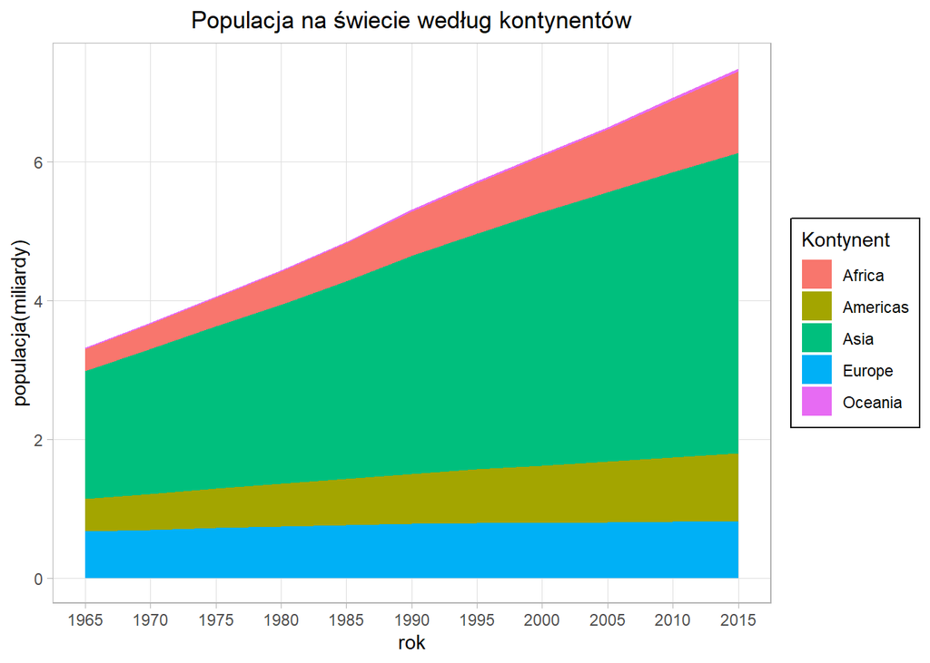

```r
p
```

# Pytanie badawcze nr2

Jak bardzo w ciągu ostatnich lat zmieniła sie średnia długość życia na poszczególnych kontynentach oraz na świecie ?

Wykres:

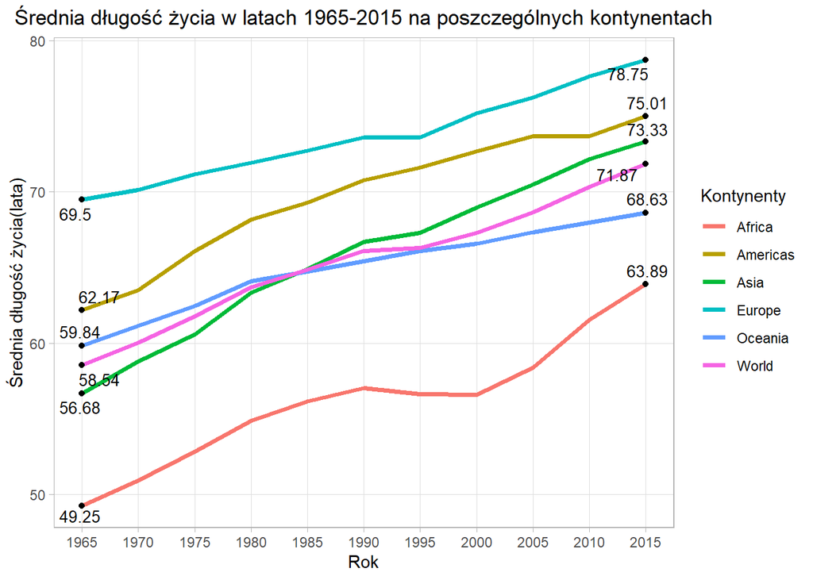

```r
lifeExpWorld <- ddply(data, .(year),summarize ,lifeExp = mean(lifeExp)) %>%
  add_column(continent = "World", .after = "year")
lifeExpCat <- ddply(data, .(year,continent), summarize ,lifeExp = mean(lifeExp))
lifeExpCat <- rbind(lifeExpWorld, lifeExpCat)
lifeExpCat$lifeExp <- round(lifeExpCat$lifeExp,2)

lifeExpCat %>%
  ggplot() +
  geom_line(mapping = aes(x = year, y = lifeExp, col = continent), size = 1.25) +
  geom_point(aes(x = year, y = round(lifeExp,2)),
            data = lifeExpCat %>% filter(year %in% c("1965","2015"))) +
  geom_text_repel(aes(label = lifeExp, x = year, y = round(lifeExp,2)),
                  data = lifeExpCat %>% filter(year %in% c("1965","2015")),
                  fontface = "plain",
                  color = "black",
                  size = 3.5) +
  scale_x_continuous(n.breaks = 10) +
  theme(panel.grid.minor = element_blank(),
        plot.title = element_text(hjust = 0.5)) +
  ggtitle("Średnia długość życia w latach 1965-2015 na poszczególnych kontynentach") +
  labs(y = "Średnia długość życia(lata)",
       x = "Rok",
       col = "Kontynenty")
```

Obliczenia:

```r
lifeExp1965 <- lifeExpCat %>% filter(year %in% c("1965")) %>%
  select(lifeExp)
lifeExp2015 <- lifeExpCat %>% filter(year %in% c("2015")) %>%
  select(continent, lifeExp)
roznica <- lifeExp2015 %>%
  cbind(lifeExp1965$lifeExp) %>%
  mutate(change = lifeExp2015$lifeExp - lifeExp1965$lifeExp) %>%
  add_column(changePercent = round((lifeExp2015$lifeExp-lifeExp1965$lifeExp)/lifeExp1965$lifeExp*100,2)) %>%
  arrange(desc(changePercent)) %>%
  dplyr::rename(lifeExp2015 = lifeExp, lifeExp1965 = "lifeExp1965$lifeExp")
roznica
```

```
##   continent lifeExp2015 lifeExp1965 change changePercent
## 1    Africa       63.89       49.25  14.64         29.73
## 2      Asia       73.33       56.68  16.65         29.38
## 3     World       71.87       58.54  13.33         22.77
## 4  Americas       75.01       62.17  12.84         20.65
## 5   Oceania       68.63       59.84   8.79         14.69
## 6    Europe       78.75       69.50   9.25         13.31
```

Powyższa tabela pokazuje o ile lat(procent) zwiększyła się przeciętna długość życia pomiędzy rokiem 1965 a 2015.

# Pytanie badawcze nr3

Jak zmieniła się liczba dzieci(0-4lata) oraz osób powyżej 65 roku życia na przestrzeni lat 1965-2015?

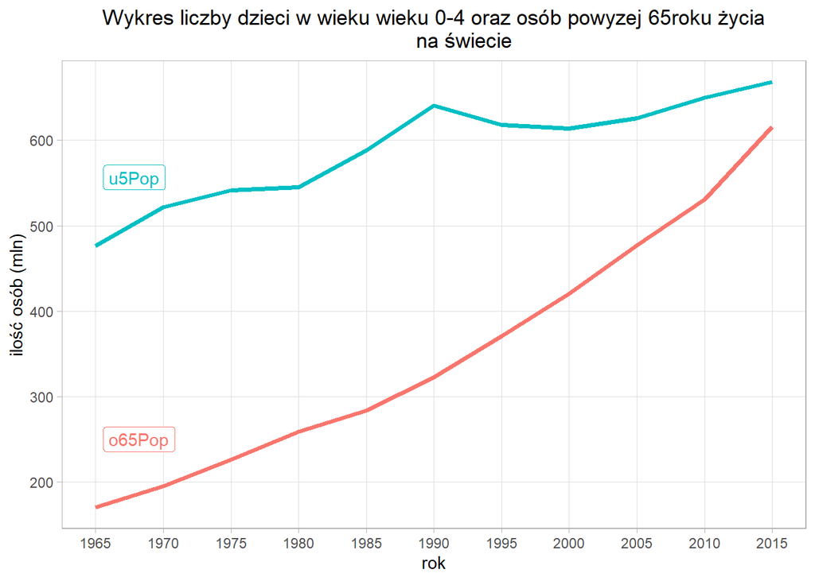

```r
totU5PopWorld <- ddply(data, .(year),summarize ,value = sum(u5Pop)) %>%
  mutate(value = round(value/1000000,2)) %>%
  mutate(type = "u5Pop")

totO65PopWorld <- ddply(data, .(year), summarize, value = sum(o65Pop)) %>%
  mutate(value = round(value/1000000,2)) %>%
  mutate(type = "o65Pop")

data3raw <- rbind(totU5PopWorld, totO65PopWorld)

totPop <- ddply(data, .(year), summarize, value = sum(popTotal)) %>%
  mutate(value = round(value/1000000,2))

totChildPopWorldPercent <- totU5PopWorld %>%
  mutate(value = value/totPop$value*100)
totPop65WorldPercent <- totO65PopWorld %>%
  mutate(value = value/totPop$value*100)

data3percent <- rbind(totChildPopWorldPercent, totPop65WorldPercent)

data3raw %>%
  ggplot() +
  geom_line(aes(x = year, y = value, col = type),size = 1.25) +
  labs(title ="Wykres liczby dzieci w wieku wieku 0-4 oraz osób powyzej 65roku życia\
          na świecie",
       x = "rok",
       y = "ilość osób (mln)") +
  scale_x_continuous(n.breaks = 10) +
  geom_label_repel(aes(x = year, y = value + 80, col = type, label = type),
                  data = data3raw %>% filter(year == 1965)) +
  theme(panel.grid.minor = element_blank(),
        plot.title = element_text(hjust = 0.5),
        legend.position = "none")
```

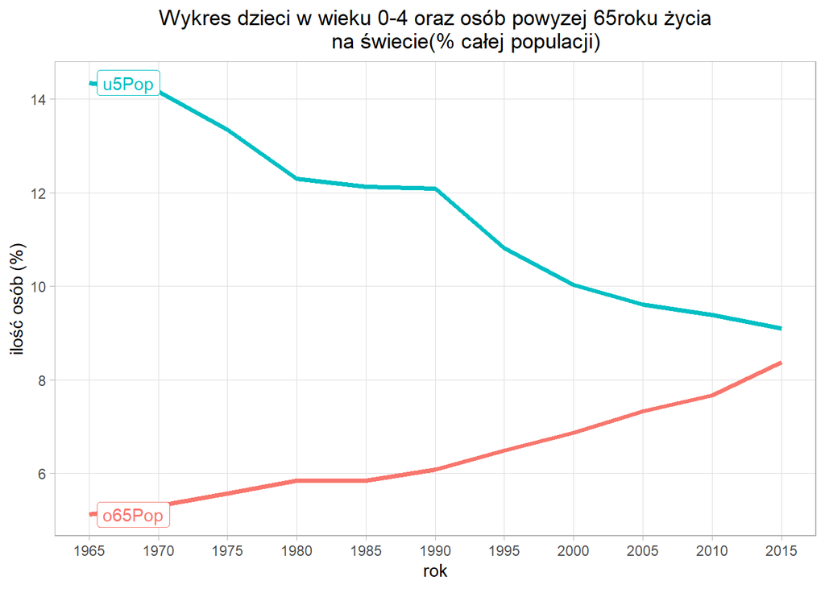

```r
data3percent %>%
  ggplot() +
  geom_line(aes(x = year, y = value, col = type),size = 1.25) +
  labs(title ="Wykres dzieci w wieku 0-4 oraz osób powyzej 65roku życia\
          na świecie(% całej populacji)",
       x = "rok",
       y = "ilość osób (%)") +
  scale_x_continuous(n.breaks = 10) +
  scale_y_continuous(n.breaks = 6) +
  geom_label_repel(aes(x = year, y = value, col = type, label = type),
                   data = data3percent %>% filter(year == 1965)) +
  theme(panel.grid.minor = element_blank(),
        plot.title = element_text(hjust = 0.5),
        legend.position = "none")
```

Analizując wykresy widzimy, że ilość seniorów rośnie znacząco szybciej od liczby dzieci poniżej 5lat, można spodziewać się że w roku 2020 jest już ona wyższa od liczby dzieci. Nie powinno nas to dziwić zważywszy na to że oczekiwana długość życia również znacząco wzrosła

# Pytanie badawcze nr4

Obecnie liczba dzieci w wieku 0-4lata jest bliska liczbie osób powyżej 65 roku życia, ale jak ten stosunek jest rozmieszczony w poszczególnych regionach świata ?

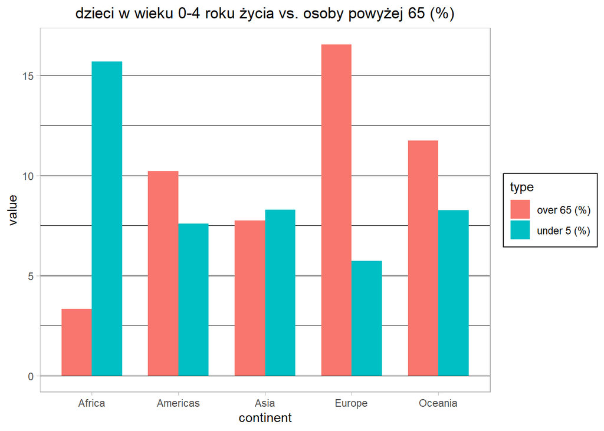

```r
data2015 <- data %>% filter(year == 2015)
totalCont <- ddply(data2015, .(continent),summarize, value = sum(popTotal))

u5Cont <- ddply(data2015, .(continent),summarize, value = sum(u5Pop)) %>%
  mutate(value = round(value/totalCont$value*100,2)) %>%
  mutate(type = "under 5 (%)")
o65Cont <- ddply(data2015, .(continent),summarize, value = sum(o65Pop)) %>%
  mutate(value = round(value/totalCont$value*100,2)) %>%
  mutate(type = "over 65 (%)")

wykres3 <- rbind(u5Cont,o65Cont)

ggplot(wykres3, aes(fill=type, y=value, x=continent)) +
  geom_bar(position = "dodge",stat = "identity", width = 0.7) +
  labs(title = "dzieci w wieku 0-4 roku życia vs. osoby powyżej 65 (%)") +
  theme( plot.background = element_rect(fill='transparent', color=NA),
         panel.grid.major.y = element_line(size=.1, color="black"),
         panel.grid.major.x = element_blank(),
         panel.grid.minor.y = element_line(size=.1, color="black"),
         legend.background = element_rect(fill='transparent'),
         legend.box.background = element_rect(fill='transparent'),
         plot.title = element_text(hjust = 0.5)
         )
```

Analizując wykres można zobaczyć że największe zróżnicowanie pomiędzy dziećmi a seniorami występuje w Afryce oraz Europie. W Afryce 15.7% ludności to dzieci poniżej 5 roku życia, natomiast osoby powyżej 65 roku życia to jedyne 3.35%. W Europie sytuacja wygląda odwrotnie: 16.55% to osoby powyżej 65 roku życia natomiast dzieci to tylko 5.72%.

# Pytanie badawcze nr5

Czy dochód jest zkorelowany z liczbą dzieci przypadających na kobiete?

Wykres:

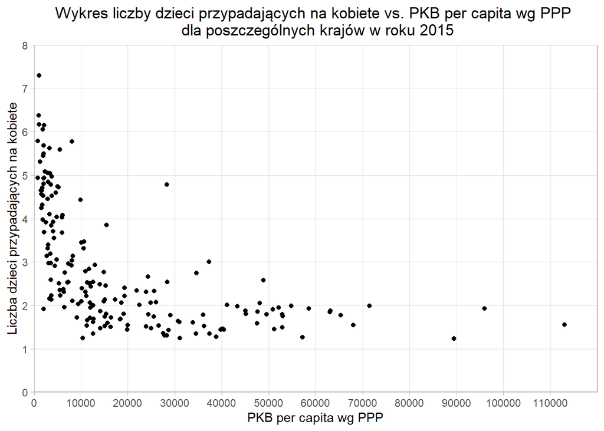

```r
data2015 <- data %>% filter(year == 2015)
data2015 %>%
  ggplot() +
  geom_point(mapping = aes(x = income, y = childWoman)) +
  scale_x_continuous(expand = c(0, 0), limits = c(0, 120000), breaks = seq(0,110000,10000)) +
  scale_y_continuous(expand = c(0, 0), limits = c(0, 8), breaks = seq(0,8,1)) +
  theme(panel.grid.minor = element_blank(),
        plot.title = element_text(hjust = 0.5)) +
  ggtitle("Wykres liczby dzieci przypadających na kobiete vs. PKB per capita wg PPP \n dla poszczególnych krajów w roku 2015") +
  labs(y = "Liczba dzieci przypadających na kobiete",
       x = "PKB per capita wg PPP")
```

Jak widac na wykresie, współcześnie wraz ze zwrostem przychodu tendencja do posiadania wiekszej ilości dzieci przez kobiety maleje.

Zobaczmy co mówi współczynnik korelacji pearsona jak i również na temat lat poprzednich.

Obliczenia:

```r
FUNcor <- function(x)
{
  return(data.frame(COR = cor(x$childWoman, x$income)))
}
ddply(data, .(year), FUNcor)
```

```
##    year        COR
## 1  1965 -0.2248659
## 2  1970 -0.1501066
## 3  1975 -0.2586649
## 4  1980 -0.3507021
## 5  1985 -0.5213356
## 6  1990 -0.5833343
## 7  1995 -0.5320566
## 8  2000 -0.5073899
## 9  2005 -0.5198042
## 10 2010 -0.5493698
## 11 2015 -0.5594409
```

Możemy zauważyc że znacząca korelacja wystepuje dopiero po 1980 roku. Wnioskując, liczba dzieci przypadajacych na kobiete oraz PKB/capita (PPP) są umiarkowanie ze sobą skorelowane. Wraz z wzrostem PKB liczba dzieci przypadających na kobiete maleje.

# Pytanie badawcze nr 6

Na wcześniejszych wykresach można było zauważyć że w biedniejszych krajach kobiety chętniej posiadają dzieci jak i również oczekiwana długość życia jest mniejsza. Przekłada się to na mniejszą mediane wieku w tych krajach.

Jak wpływa to na ogólny wzrost populacji ? Czy kraje z mniejszą medianą wieku mają tendencje do większego wzrostu liczby ludności ?

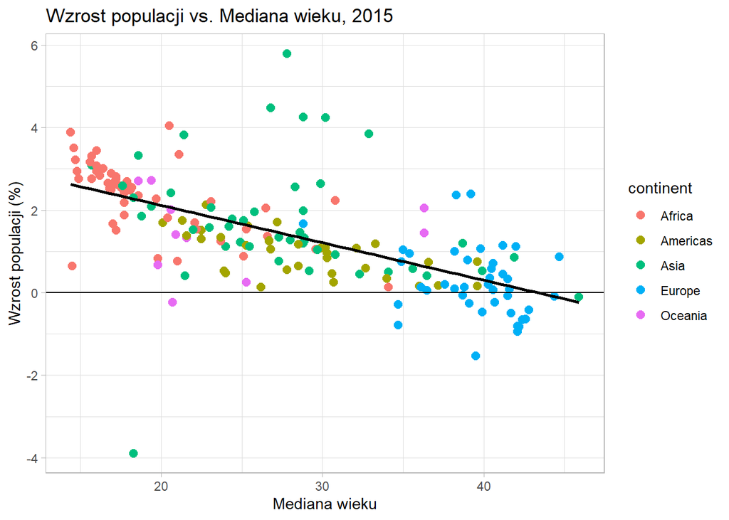

```r
data2015 <- data %>% filter(year == 2015)
data2015 %>%
  ggplot() +
  geom_point(aes(x = medianAge, y = popGrowth, col = continent), size = 2.5) +
  geom_smooth(aes(x = medianAge, y = popGrowth), method=lm, col = "black", se = FALSE) +
  geom_hline(yintercept = 0) +
  labs(title = "Wzrost populacji vs. Mediana wieku, 2015",
       y = "Wzrost populacji (%)",
       x = "Mediana wieku") +
  theme_light()
```

Jak widać na wykresie kraje z mniejszą medianą wieku mają tendencje do większego wzrostu populacji. Obliczmy do tego jeszcze korelacje pearsona:

```r
cor(data2015$medianAge,data2015$popGrowth)
```

```
## [1] -0.6272629
```

Wszystko się zgadza. Występuje średnia ujemna korelacja.